# Project 3

STATS 220 Semester One 2023

(Alex) Jiacheng Wei

2023-04-28

# Introduction

### Aim

The situation I have curated the playlist for are situations where crime occurs, and the criminals wish to have some music playing for them. The kind of songs I wanted on my playlist were cheap songs about criminals (2 United States Dollars or less).

### Data Manipulation

One data manipulation which I used to help me find the songs I need for my playlist is using “filter(str_detect(kind,”song”))“.

There exists some objects in the original query which were not songs. I did not wish for an audio-book or podcast to play as the aim of the playlist is to play songs.

| Song Names |
| --- |
| Criminal |
| Criminal |
| Criminal |
| Criminal |
| Criminal |
| Criminal |
| Smooth Criminal |
| Criminal |
| Criminal |
| Criminal (feat. Rick Ross) |
| Criminal |
| Criminal |
| Smooth Criminal |
| Criminal |
| Criminal |
| Criminal |
| Criminal |
| Criminal (feat. Ariana Savalas) |
| Criminal |
| Criminal |

### Advantages of JSON

Nested JSON allows for hierarchical organisation of data with nested levels of information. As each value can contain it’s own set of key-value pairs and as nesting is allowed, complex relationships and structures can be represented in a compact and standardised way.

An example is the reality of multiple genres and/or sub-genres. Each genre/sub-genre could be represented as a nested object under a key such as “genres” or “sub-genres”.

This implementation of nested JSON allows for flexible and structured representation of the genres. This allows for easier analysis of songs based on their genres and sub-genres.

# Key features of my playlist

1. The graph which shows the percentage of songs which are explicit in the playlist grouped by a song’s primary genre.
2. An annotation underneath the graph which gives the percentage of the largest percentage on the graph.
3. The mean price of a given song in a given currency.
4. How many seconds in the longest song of the playlist.

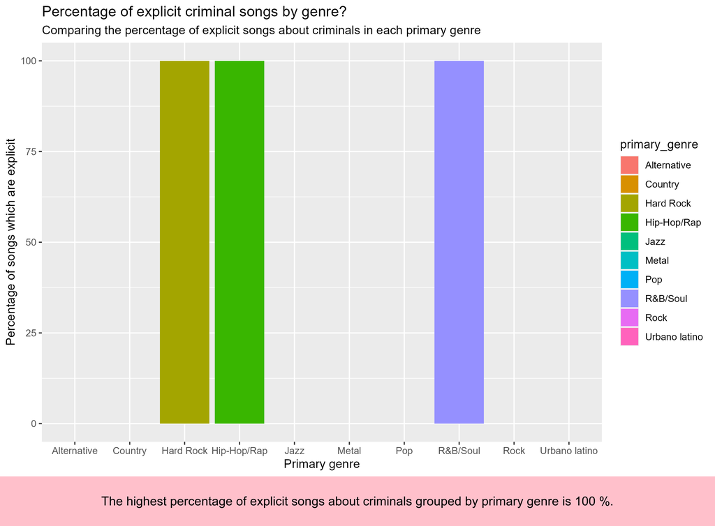

**-The mean price for a song in the playlist is 1.29 in USD.**

**-The longest song in the playlist is 342.533 seconds long.**

# SQL Examples

```
SELECT trackViewUrl AS track_url,
       trackPrice AS price,
       durationMillisecond / 1000 AS duration_seconds,
       primaryGenreName AS primary_genre,
       trackExplicitness AS explicitness,
       LENGTH(trackName) AS track_name_length,
       trackName AS track,
       LENGTH(artistName) AS artist_name_length,
       artistName AS artist
FROM tbl_songs
WHERE price <= 2.00
LIMIT 20;
```

### Two Examples of SQL

“SELECT” allows for customising the specific variables we wish to have in our table. “LIMIT” allows for limiting the amount of objects in the table.

# Learning Reflection

### One Important Idea

One important idea I have internalised is how databases and database manipulation can come in different forms and/or different places.

Databases can come in forms of google forms or queries from API’s as used in this project.

Database manipulation can be done in SQL as demonstrated in the code snippet above or with “r” from the “R project” while utlising the {tidyverse} library.

### Creativity

I have demonstrated creativity in this project by analysing the percentages of explicit songs grouped by the song’s primary genres and made a graphic in the form of a bar graph. I have gone beyond and also merged an image of a custom adaptive annotation (it changes the value of the maximum percentage in the text accordingly).

### Data Technology Curiosities for the Future

Some other topics related to Data Technology which I am interested in is analysing data on an even deeper level beyond simple bar graphs. Perhaps making 3D models. These more complicated data communication models could also possibly be used to make animations which show change in data over a period of time which allows for interesting trends and characteristics of a given data-set to hopefully become a little more apparent to a human viewer.

# Appendix

```r
library(tidyverse)
library(jsonlite)
library(dplyr)
library(magick)

query_1 <- "https://itunes.apple.com/search?term=stealing+things&limit=200"
response_example <- fromJSON(query_1)

# Cheap songs about criminals with no explicit language
# Aim is a playlist of affordable songs to be used while committing crimes with your whole family
# Affordable in this case means 2 dollars USD or less
query_actual <- "https://itunes.apple.com/search?term=criminal&limit=200"
response <- fromJSON(query_actual)
initial_playlist <- response$results

# Query is "criminal". Affordable songs for committing crime
# Make highly customised playlist catering to our aims
my_playlist <- initial_playlist %>%
  filter(str_detect(kind, "song")) %>%
  mutate(artistNameLength = nchar(artistName),
         trackNameLength = nchar(trackName),
         durationSeconds = trackTimeMillis / 1000) %>%
  select(artistName,
         artistNameLength,
         trackName,
         trackNameLength,
         trackExplicitness,
         primaryGenreName,
         trackPrice,
         durationSeconds,
         trackViewUrl,
         currency) %>%
  rename(artist = 1,
         artist_name_length = 2,
         track = 3,
         track_name_length = 4,
         explicitness = 5,
         primary_genre = 6,
         price= 7,
         duration_seconds = 8,
         track_url = 9) %>%
  slice(1:20)

# my_playlist %>%
#  print()

# Write my_playlist as an CSV
write_csv(my_playlist, "my_playlist.csv")

# Group by a variable and summarise.
# Gets the percentage of songs which are explicit for each primary genre
percentage_data <- my_playlist %>%
  group_by(primary_genre) %>%
  summarise(percentage_explicit_songs = round(sum(explicitness == "explicit") / n(), 2) * 100)

# Using knowledge from previous assignments to make a bar graph
percentage_data_graph <- ggplot (data = percentage_data) +
  geom_col(aes(x = primary_genre, y = percentage_explicit_songs, fill = primary_genre)) +
  coord_cartesian(ylim = c(0, 100))+
  labs(title = "Percentage of explicit criminal songs by genre?",subtitle = "Comparing the percentage of explicit songs about criminals in each primary genre", x = "Primary genre", y = "Percentage of songs which are explicit")

ggsave("percentage_data_graph.png", percentage_data_graph, height = 6, width = 9, dpi = 320)

# Create an annotated image
graph_image <- image_read("percentage_data_graph.png")

maximum_percentage <- percentage_data$percentage_explicit_songs %>%
  max()

annotation_text <- paste("The highest percentage of explicit songs about criminals grouped by primary genre is", maximum_percentage, "%.")
annotation_text_image <- image_blank(color = "pink", height = 200, width = (9 * 320)) %>%
  image_annotate(annotation_text, size = 50, gravity = "center")
annotation_text_image %>%
  image_write("annotation.png")

annotation_image_vector <- c(graph_image, annotation_text_image)

annotated_graph_image <- image_append(annotation_image_vector, stack = TRUE)
annotated_graph_image %>%
  image_write("annotated_percentage_data_graph.png")
```